# Capstone Project Solution

This is the implementation of the AdaBoost and Deep Neural Network (DNN) solutions to the Breast Cancer Wisconsin (Diagnostic) Data Set. The files used for this code is outlined in the README.md file.

## Import Modules

- pandas
- numpy
- matplotlib
- seaborn
- time

```python
import pandas as pd
import numpy as np
import matplotlib.pyplot as plt
%matplotlib inline
import seaborn as sns
import time as tm
```

## Reading in the Data

- Unzip the data file `breast-cancer-wisconsin-data`
- Read the data into a Pandas DataFrame

```python
from zipfile import ZipFile
with ZipFile('breast-cancer-wisconsin-data.zip') as zipdata:
    with zipdata.open('data.csv') as rawdata:
        df = pd.read_csv(rawdata)
```

```python
df.head()
```

|  | id | diagnosis | radius_mean | texture_mean | perimeter_mean | area_mean | smoothness_mean | compactness_mean | concavity_mean | concave points_mean | ... | texture_worst | perimeter_worst | area_worst | smoothness_worst | compactness_worst | concavity_worst | concave points_worst | symmetry_worst | fractal_dimension_worst | Unnamed: 32 |
| --- | --- | --- | --- | --- | --- | --- | --- | --- | --- | --- | --- | --- | --- | --- | --- | --- | --- | --- | --- | --- | --- |
| 0 | 842302 | M | 17.99 | 10.38 | 122.80 | 1001.0 | 0.11840 | 0.27760 | 0.3001 | 0.14710 | ... | 17.33 | 184.60 | 2019.0 | 0.1622 | 0.6656 | 0.7119 | 0.2654 | 0.4601 | 0.11890 | NaN |
| 1 | 842517 | M | 20.57 | 17.77 | 132.90 | 1326.0 | 0.08474 | 0.07864 | 0.0869 | 0.07017 | ... | 23.41 | 158.80 | 1956.0 | 0.1238 | 0.1866 | 0.2416 | 0.1860 | 0.2750 | 0.08902 | NaN |
| 2 | 84300903 | M | 19.69 | 21.25 | 130.00 | 1203.0 | 0.10960 | 0.15990 | 0.1974 | 0.12790 | ... | 25.53 | 152.50 | 1709.0 | 0.1444 | 0.4245 | 0.4504 | 0.2430 | 0.3613 | 0.08758 | NaN |
| 3 | 84348301 | M | 11.42 | 20.38 | 77.58 | 386.1 | 0.14250 | 0.28390 | 0.2414 | 0.10520 | ... | 26.50 | 98.87 | 567.7 | 0.2098 | 0.8663 | 0.6869 | 0.2575 | 0.6638 | 0.17300 | NaN |
| 4 | 84358402 | M | 20.29 | 14.34 | 135.10 | 1297.0 | 0.10030 | 0.13280 | 0.1980 | 0.10430 | ... | 16.67 | 152.20 | 1575.0 | 0.1374 | 0.2050 | 0.4000 | 0.1625 | 0.2364 | 0.07678 | NaN |

5 rows × 33 columns

```python
data = df.drop(['id', 'Unnamed: 32'], axis=1)
```

```python
data.head()
```

|  | diagnosis | radius_mean | texture_mean | perimeter_mean | area_mean | smoothness_mean | compactness_mean | concavity_mean | concave points_mean | symmetry_mean | ... | radius_worst | texture_worst | perimeter_worst | area_worst | smoothness_worst | compactness_worst | concavity_worst | concave points_worst | symmetry_worst | fractal_dimension_worst |
| --- | --- | --- | --- | --- | --- | --- | --- | --- | --- | --- | --- | --- | --- | --- | --- | --- | --- | --- | --- | --- | --- |
| 0 | M | 17.99 | 10.38 | 122.80 | 1001.0 | 0.11840 | 0.27760 | 0.3001 | 0.14710 | 0.2419 | ... | 25.38 | 17.33 | 184.60 | 2019.0 | 0.1622 | 0.6656 | 0.7119 | 0.2654 | 0.4601 | 0.11890 |
| 1 | M | 20.57 | 17.77 | 132.90 | 1326.0 | 0.08474 | 0.07864 | 0.0869 | 0.07017 | 0.1812 | ... | 24.99 | 23.41 | 158.80 | 1956.0 | 0.1238 | 0.1866 | 0.2416 | 0.1860 | 0.2750 | 0.08902 |
| 2 | M | 19.69 | 21.25 | 130.00 | 1203.0 | 0.10960 | 0.15990 | 0.1974 | 0.12790 | 0.2069 | ... | 23.57 | 25.53 | 152.50 | 1709.0 | 0.1444 | 0.4245 | 0.4504 | 0.2430 | 0.3613 | 0.08758 |
| 3 | M | 11.42 | 20.38 | 77.58 | 386.1 | 0.14250 | 0.28390 | 0.2414 | 0.10520 | 0.2597 | ... | 14.91 | 26.50 | 98.87 | 567.7 | 0.2098 | 0.8663 | 0.6869 | 0.2575 | 0.6638 | 0.17300 |
| 4 | M | 20.29 | 14.34 | 135.10 | 1297.0 | 0.10030 | 0.13280 | 0.1980 | 0.10430 | 0.1809 | ... | 22.54 | 16.67 | 152.20 | 1575.0 | 0.1374 | 0.2050 | 0.4000 | 0.1625 | 0.2364 | 0.07678 |

5 rows × 31 columns

```python
X = data.drop('diagnosis', axis=1)
y_label = data['diagnosis']
y = y_label.apply(lambda x: int(x=='M')) # 1: Malignant, 0: Benign
```

## Data Exploration

We will explore the data by looking at the following characteristics of the data:

- Find the number of samples and features
- Find the number of Malignant and Benign labels
- Identify any missing or corrupted data
- Examine basic statistics of the data
- Investigate which features are correlated.

```python
X.describe()
```

|  | radius_mean | texture_mean | perimeter_mean | area_mean | smoothness_mean | compactness_mean | concavity_mean | concave points_mean | symmetry_mean | fractal_dimension_mean | ... | radius_worst | texture_worst | perimeter_worst | area_worst | smoothness_worst | compactness_worst | concavity_worst | concave points_worst | symmetry_worst | fractal_dimension_worst |
| --- | --- | --- | --- | --- | --- | --- | --- | --- | --- | --- | --- | --- | --- | --- | --- | --- | --- | --- | --- | --- | --- |
| count | 569.000000 | 569.000000 | 569.000000 | 569.000000 | 569.000000 | 569.000000 | 569.000000 | 569.000000 | 569.000000 | 569.000000 | ... | 569.000000 | 569.000000 | 569.000000 | 569.000000 | 569.000000 | 569.000000 | 569.000000 | 569.000000 | 569.000000 | 569.000000 |
| mean | 14.127292 | 19.289649 | 91.969033 | 654.889104 | 0.096360 | 0.104341 | 0.088799 | 0.048919 | 0.181162 | 0.062798 | ... | 16.269190 | 25.677223 | 107.261213 | 880.583128 | 0.132369 | 0.254265 | 0.272188 | 0.114606 | 0.290076 | 0.083946 |
| std | 3.524049 | 4.301036 | 24.298981 | 351.914129 | 0.014064 | 0.052813 | 0.079720 | 0.038803 | 0.027414 | 0.007060 | ... | 4.833242 | 6.146258 | 33.602542 | 569.356993 | 0.022832 | 0.157336 | 0.208624 | 0.065732 | 0.061867 | 0.018061 |
| min | 6.981000 | 9.710000 | 43.790000 | 143.500000 | 0.052630 | 0.019380 | 0.000000 | 0.000000 | 0.106000 | 0.049960 | ... | 7.930000 | 12.020000 | 50.410000 | 185.200000 | 0.071170 | 0.027290 | 0.000000 | 0.000000 | 0.156500 | 0.055040 |
| 25% | 11.700000 | 16.170000 | 75.170000 | 420.300000 | 0.086370 | 0.064920 | 0.029560 | 0.020310 | 0.161900 | 0.057700 | ... | 13.010000 | 21.080000 | 84.110000 | 515.300000 | 0.116600 | 0.147200 | 0.114500 | 0.064930 | 0.250400 | 0.071460 |
| 50% | 13.370000 | 18.840000 | 86.240000 | 551.100000 | 0.095870 | 0.092630 | 0.061540 | 0.033500 | 0.179200 | 0.061540 | ... | 14.970000 | 25.410000 | 97.660000 | 686.500000 | 0.131300 | 0.211900 | 0.226700 | 0.099930 | 0.282200 | 0.080040 |
| 75% | 15.780000 | 21.800000 | 104.100000 | 782.700000 | 0.105300 | 0.130400 | 0.130700 | 0.074000 | 0.195700 | 0.066120 | ... | 18.790000 | 29.720000 | 125.400000 | 1084.000000 | 0.146000 | 0.339100 | 0.382900 | 0.161400 | 0.317900 | 0.092080 |
| max | 28.110000 | 39.280000 | 188.500000 | 2501.000000 | 0.163400 | 0.345400 | 0.426800 | 0.201200 | 0.304000 | 0.097440 | ... | 36.040000 | 49.540000 | 251.200000 | 4254.000000 | 0.222600 | 1.058000 | 1.252000 | 0.291000 | 0.663800 | 0.207500 |

8 rows × 30 columns

## Data Integrity

- Check for missing or NaN data
- Drop rows with poorly defined data points, if any.
- Count the number of labels.

```python
allNaNs = X.isnull()
count = allNaNs.sum()
print(f'Count of NaN values = {count}')
```

```
Count of NaN values = radius_mean                0
texture_mean               0
perimeter_mean             0
area_mean                  0
smoothness_mean            0
compactness_mean           0
concavity_mean             0
concave points_mean        0
symmetry_mean              0
fractal_dimension_mean     0
radius_se                  0
texture_se                 0
perimeter_se               0
area_se                    0
smoothness_se              0
compactness_se             0
concavity_se               0
concave points_se          0
symmetry_se                0
fractal_dimension_se       0
radius_worst               0
texture_worst              0
perimeter_worst            0
area_worst                 0
smoothness_worst           0
compactness_worst          0
concavity_worst            0
concave points_worst       0
symmetry_worst             0
fractal_dimension_worst    0
dtype: int64
```

```python
print(f'Feature Set size = {X.shape[0]} rows, {X.shape[1]} columns')
```

```
Feature Set size = 569 rows, 30 columns
```

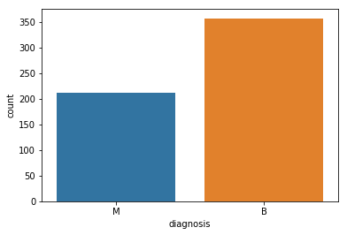

```python
sns.countplot(y_label, label='Count')
```

## Correlations

```python
features_mean = X.iloc[:, 0:10]
features_se = X.iloc[:, 10:20]
features_worst = X.iloc[:, 20:30]
features_worst.head()
```

|  | radius_worst | texture_worst | perimeter_worst | area_worst | smoothness_worst | compactness_worst | concavity_worst | concave points_worst | symmetry_worst | fractal_dimension_worst |
| --- | --- | --- | --- | --- | --- | --- | --- | --- | --- | --- |
| 0 | 25.38 | 17.33 | 184.60 | 2019.0 | 0.1622 | 0.6656 | 0.7119 | 0.2654 | 0.4601 | 0.11890 |
| 1 | 24.99 | 23.41 | 158.80 | 1956.0 | 0.1238 | 0.1866 | 0.2416 | 0.1860 | 0.2750 | 0.08902 |
| 2 | 23.57 | 25.53 | 152.50 | 1709.0 | 0.1444 | 0.4245 | 0.4504 | 0.2430 | 0.3613 | 0.08758 |
| 3 | 14.91 | 26.50 | 98.87 | 567.7 | 0.2098 | 0.8663 | 0.6869 | 0.2575 | 0.6638 | 0.17300 |
| 4 | 22.54 | 16.67 | 152.20 | 1575.0 | 0.1374 | 0.2050 | 0.4000 | 0.1625 | 0.2364 | 0.07678 |

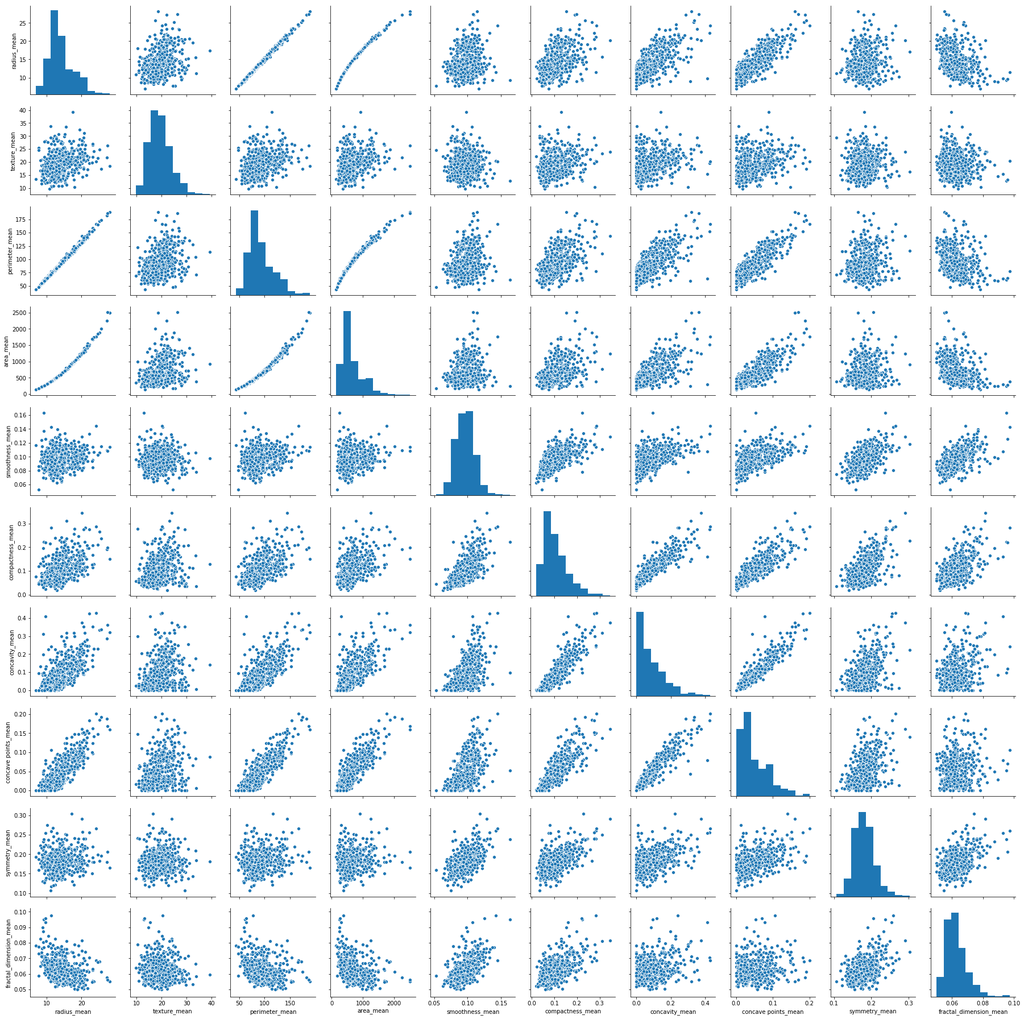

```python
sns.pairplot(features_mean)
```

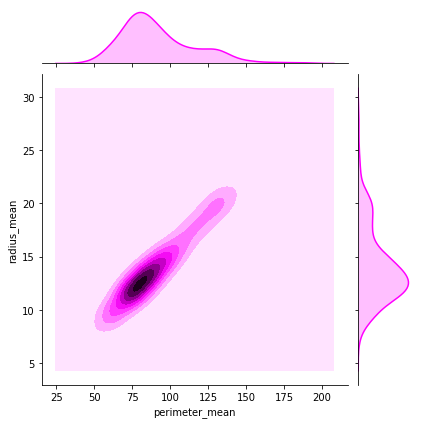

```python
sns.jointplot(features_mean.perimeter_mean, features_mean.radius_mean, kind='kde', color='magenta')
```

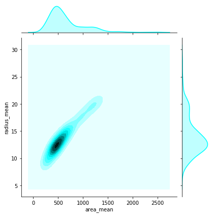

```python
sns.jointplot(features_mean.area_mean, features_mean.radius_mean, kind='kde', color='cyan')
```

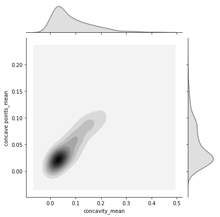

```python
sns.jointplot(features_mean.concavity_mean, features_mean['concave points_mean'], kind='kde', color='grey')
```

## Distributions

We will use boxplots to gain insight inot how the data is distributed for each of the aggregation categories, mean, SE and worst.

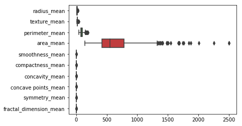

```python
#plt.figure(figsize=(8, 12))
sns.boxplot(data=features_mean, dodge=True, orient='h')
```

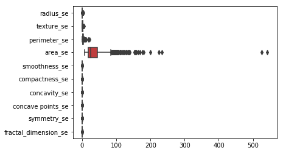

```python
sns.boxplot(data=features_se, dodge=True, orient='h')
```

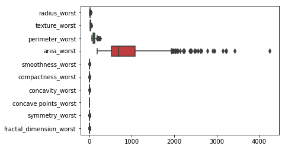

```python
sns.boxplot(data=features_worst, dodge=True, orient='h')
```

## Normalization

Based on the boxplots above, we can see that not all features are within the same range. For a fair comparison and also for the DNN model we will implement later, we will need the feature ranges to be normalized between `[0, 1]`. We will use the MinMaxScaler preprocessing module to do that.

```python
from sklearn.preprocessing import MinMaxScaler
scaler = MinMaxScaler()
Xarr = X.to_numpy()
Xn = pd.DataFrame(data=scaler.fit_transform(Xarr), columns=X.columns)
Xn_mean = Xn.iloc[:,0:10]
Xn_se = Xn.iloc[:,10:20]
Xn_worst = Xn.iloc[:,20:30]
```

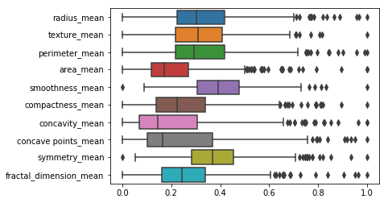

```python
sns.boxplot(data=Xn_mean, dodge=True, orient='h')
```

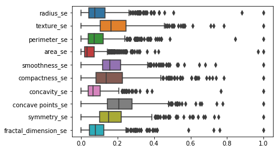

```python
sns.boxplot(data=Xn_se, dodge=True, orient='h')
```

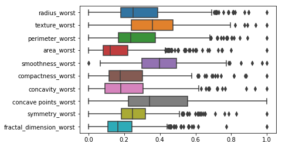

```python
sns.boxplot(data=Xn_worst, dodge=True, orient='h')
```

## Feature Selection

In this section, we will use the Low Variance method to see if there are any features that could be excluded. We will use a Low Variance threshold value of `0.9 x (1 - 0.9)`.

```python
from sklearn.feature_selection import VarianceThreshold
sel = VarianceThreshold(threshold=(.9 * (1 - .9)))
Xv = sel.fit_transform(X, y)
```

```python
ndx = sel.get_support(indices=True)
print(f'column indices = {ndx}')
features_rem = np.array2string(X.columns[ndx])
print(f'Feaatures remaining = {features_rem}')
print(f'Number of features remaining = {len(X.columns[ndx])}')
```

```
column indices = [ 0  1  2  3 11 12 13 20 21 22 23]
Feaatures remaining = ['radius_mean' 'texture_mean' 'perimeter_mean' 'area_mean' 'texture_se'
 'perimeter_se' 'area_se' 'radius_worst' 'texture_worst' 'perimeter_worst'
 'area_worst']
Number of features remaining = 11
```

```python
Xfs = X.iloc[:,ndx]
Xfs.head()
```

|  | radius_mean | texture_mean | perimeter_mean | area_mean | texture_se | perimeter_se | area_se | radius_worst | texture_worst | perimeter_worst | area_worst |
| --- | --- | --- | --- | --- | --- | --- | --- | --- | --- | --- | --- |
| 0 | 17.99 | 10.38 | 122.80 | 1001.0 | 0.9053 | 8.589 | 153.40 | 25.38 | 17.33 | 184.60 | 2019.0 |
| 1 | 20.57 | 17.77 | 132.90 | 1326.0 | 0.7339 | 3.398 | 74.08 | 24.99 | 23.41 | 158.80 | 1956.0 |
| 2 | 19.69 | 21.25 | 130.00 | 1203.0 | 0.7869 | 4.585 | 94.03 | 23.57 | 25.53 | 152.50 | 1709.0 |
| 3 | 11.42 | 20.38 | 77.58 | 386.1 | 1.1560 | 3.445 | 27.23 | 14.91 | 26.50 | 98.87 | 567.7 |
| 4 | 20.29 | 14.34 | 135.10 | 1297.0 | 0.7813 | 5.438 | 94.44 | 22.54 | 16.67 | 152.20 | 1575.0 |

```python
Xnfs = Xn.iloc[:,ndx]
Xnfs.head()
```

|  | radius_mean | texture_mean | perimeter_mean | area_mean | texture_se | perimeter_se | area_se | radius_worst | texture_worst | perimeter_worst | area_worst |
| --- | --- | --- | --- | --- | --- | --- | --- | --- | --- | --- | --- |
| 0 | 0.521037 | 0.022658 | 0.545989 | 0.363733 | 0.120469 | 0.369034 | 0.273811 | 0.620776 | 0.141525 | 0.668310 | 0.450698 |
| 1 | 0.643144 | 0.272574 | 0.615783 | 0.501591 | 0.082589 | 0.124440 | 0.125660 | 0.606901 | 0.303571 | 0.539818 | 0.435214 |
| 2 | 0.601496 | 0.390260 | 0.595743 | 0.449417 | 0.094303 | 0.180370 | 0.162922 | 0.556386 | 0.360075 | 0.508442 | 0.374508 |
| 3 | 0.210090 | 0.360839 | 0.233501 | 0.102906 | 0.175875 | 0.126655 | 0.038155 | 0.248310 | 0.385928 | 0.241347 | 0.094008 |
| 4 | 0.629893 | 0.156578 | 0.630986 | 0.489290 | 0.093065 | 0.220563 | 0.163688 | 0.519744 | 0.123934 | 0.506948 | 0.341575 |

## Comment on Low Variance method

The low variance method does not seem to be a good method for selecting features from our data set. On the normalized feature set, there are no features that can be removed with a 90% low variance threshold. Since we know that radius, area and perimiter are funtionally related, as well as concavity and concave points, using a correlation method may be more suitable.

## Feature Correlation

We will use pandas `corr()` functions for dataframes to calculate the Pearsons Correlation coefficients. This will only confirm what we were able to see from the pairplots above. However, we should be able to make more informed decisions looking at the numerical values of the correlation coefficients.

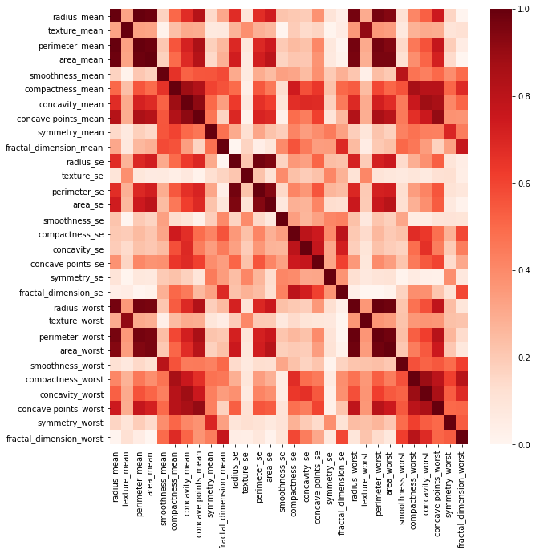

```python
Xcor = X.corr().abs()
plt.figure(figsize=(10,10))
sns.heatmap(Xcor, cmap=plt.cm.Reds)
```

```python
Xcor.head()
```

|  | radius_mean | texture_mean | perimeter_mean | area_mean | smoothness_mean | compactness_mean | concavity_mean | concave points_mean | symmetry_mean | fractal_dimension_mean | ... | radius_worst | texture_worst | perimeter_worst | area_worst | smoothness_worst | compactness_worst | concavity_worst | concave points_worst | symmetry_worst | fractal_dimension_worst |
| --- | --- | --- | --- | --- | --- | --- | --- | --- | --- | --- | --- | --- | --- | --- | --- | --- | --- | --- | --- | --- | --- |
| radius_mean | 1.000000 | 0.323782 | 0.997855 | 0.987357 | 0.170581 | 0.506124 | 0.676764 | 0.822529 | 0.147741 | 0.311631 | ... | 0.969539 | 0.297008 | 0.965137 | 0.941082 | 0.119616 | 0.413463 | 0.526911 | 0.744214 | 0.163953 | 0.007066 |
| texture_mean | 0.323782 | 1.000000 | 0.329533 | 0.321086 | 0.023389 | 0.236702 | 0.302418 | 0.293464 | 0.071401 | 0.076437 | ... | 0.352573 | 0.912045 | 0.358040 | 0.343546 | 0.077503 | 0.277830 | 0.301025 | 0.295316 | 0.105008 | 0.119205 |
| perimeter_mean | 0.997855 | 0.329533 | 1.000000 | 0.986507 | 0.207278 | 0.556936 | 0.716136 | 0.850977 | 0.183027 | 0.261477 | ... | 0.969476 | 0.303038 | 0.970387 | 0.941550 | 0.150549 | 0.455774 | 0.563879 | 0.771241 | 0.189115 | 0.051019 |
| area_mean | 0.987357 | 0.321086 | 0.986507 | 1.000000 | 0.177028 | 0.498502 | 0.685983 | 0.823269 | 0.151293 | 0.283110 | ... | 0.962746 | 0.287489 | 0.959120 | 0.959213 | 0.123523 | 0.390410 | 0.512606 | 0.722017 | 0.143570 | 0.003738 |
| smoothness_mean | 0.170581 | 0.023389 | 0.207278 | 0.177028 | 1.000000 | 0.659123 | 0.521984 | 0.553695 | 0.557775 | 0.584792 | ... | 0.213120 | 0.036072 | 0.238853 | 0.206718 | 0.805324 | 0.472468 | 0.434926 | 0.503053 | 0.394309 | 0.499316 |

5 rows × 30 columns

```python
s = Xcor.unstack()
so = s.sort_values(kind="quicksort", ascending=False)
so[so>0.9][so<1.0]
```

```
radius_mean           perimeter_mean          0.997855
perimeter_mean        radius_mean             0.997855
radius_worst          perimeter_worst         0.993708
perimeter_worst       radius_worst            0.993708
radius_mean           area_mean               0.987357
area_mean             radius_mean             0.987357
                      perimeter_mean          0.986507
perimeter_mean        area_mean               0.986507
radius_worst          area_worst              0.984015
area_worst            radius_worst            0.984015
perimeter_worst       area_worst              0.977578
area_worst            perimeter_worst         0.977578
radius_se             perimeter_se            0.972794
perimeter_se          radius_se               0.972794
perimeter_worst       perimeter_mean          0.970387
perimeter_mean        perimeter_worst         0.970387
radius_mean           radius_worst            0.969539
radius_worst          radius_mean             0.969539
                      perimeter_mean          0.969476
perimeter_mean        radius_worst            0.969476
perimeter_worst       radius_mean             0.965137
radius_mean           perimeter_worst         0.965137
area_mean             radius_worst            0.962746
radius_worst          area_mean               0.962746
area_worst            area_mean               0.959213
area_mean             area_worst              0.959213
perimeter_worst       area_mean               0.959120
area_mean             perimeter_worst         0.959120
radius_se             area_se                 0.951830
area_se               radius_se               0.951830
area_worst            perimeter_mean          0.941550
perimeter_mean        area_worst              0.941550
radius_mean           area_worst              0.941082
area_worst            radius_mean             0.941082
area_se               perimeter_se            0.937655
perimeter_se          area_se                 0.937655
concavity_mean        concave points_mean     0.921391
concave points_mean   concavity_mean          0.921391
texture_mean          texture_worst           0.912045
texture_worst         texture_mean            0.912045
concave points_worst  concave points_mean     0.910155
concave points_mean   concave points_worst    0.910155
dtype: float64
```

> NB: Credit goes to the answer on stackoverflow at [this link](https://stackoverflow.com/questions/17778394/list-highest-correlation-pairs-from-a-large-correlation-matrix-in-pandas) for the code to unstack and sort the correlation coefficients.

```python
Xcor.loc['radius_mean', 'perimeter_mean']
```

```
0.9978552814938113
```

```python
Xcor.loc['radius_mean', 'area_mean']
```

```
0.9873571700566119
```

```python
Xcor.loc['area_mean', 'perimeter_mean']
```

```
0.9865068039913906
```

```python
Xcor.loc['concavity_mean', 'concave points_mean']
```

```
0.9213910263788594
```

## Feature Filtering

```python
Xfs = X.drop(['area_mean', 'perimeter_mean', 'area_worst','perimeter_worst', 'area_se', 'perimeter_se', 'concave points_mean'], axis=1)
Xfs.head()
```

|  | radius_mean | texture_mean | smoothness_mean | compactness_mean | concavity_mean | symmetry_mean | fractal_dimension_mean | radius_se | texture_se | smoothness_se | ... | symmetry_se | fractal_dimension_se | radius_worst | texture_worst | smoothness_worst | compactness_worst | concavity_worst | concave points_worst | symmetry_worst | fractal_dimension_worst |
| --- | --- | --- | --- | --- | --- | --- | --- | --- | --- | --- | --- | --- | --- | --- | --- | --- | --- | --- | --- | --- | --- |
| 0 | 17.99 | 10.38 | 0.11840 | 0.27760 | 0.3001 | 0.2419 | 0.07871 | 1.0950 | 0.9053 | 0.006399 | ... | 0.03003 | 0.006193 | 25.38 | 17.33 | 0.1622 | 0.6656 | 0.7119 | 0.2654 | 0.4601 | 0.11890 |
| 1 | 20.57 | 17.77 | 0.08474 | 0.07864 | 0.0869 | 0.1812 | 0.05667 | 0.5435 | 0.7339 | 0.005225 | ... | 0.01389 | 0.003532 | 24.99 | 23.41 | 0.1238 | 0.1866 | 0.2416 | 0.1860 | 0.2750 | 0.08902 |
| 2 | 19.69 | 21.25 | 0.10960 | 0.15990 | 0.1974 | 0.2069 | 0.05999 | 0.7456 | 0.7869 | 0.006150 | ... | 0.02250 | 0.004571 | 23.57 | 25.53 | 0.1444 | 0.4245 | 0.4504 | 0.2430 | 0.3613 | 0.08758 |
| 3 | 11.42 | 20.38 | 0.14250 | 0.28390 | 0.2414 | 0.2597 | 0.09744 | 0.4956 | 1.1560 | 0.009110 | ... | 0.05963 | 0.009208 | 14.91 | 26.50 | 0.2098 | 0.8663 | 0.6869 | 0.2575 | 0.6638 | 0.17300 |
| 4 | 20.29 | 14.34 | 0.10030 | 0.13280 | 0.1980 | 0.1809 | 0.05883 | 0.7572 | 0.7813 | 0.011490 | ... | 0.01756 | 0.005115 | 22.54 | 16.67 | 0.1374 | 0.2050 | 0.4000 | 0.1625 | 0.2364 | 0.07678 |

5 rows × 23 columns

```python
Xnfs = X.drop(['area_mean', 'perimeter_mean', 'area_worst','perimeter_worst', 'area_se', 'perimeter_se', 'concave points_mean'], axis=1)
Xnfs.head()
```

|  | radius_mean | texture_mean | smoothness_mean | compactness_mean | concavity_mean | symmetry_mean | fractal_dimension_mean | radius_se | texture_se | smoothness_se | ... | symmetry_se | fractal_dimension_se | radius_worst | texture_worst | smoothness_worst | compactness_worst | concavity_worst | concave points_worst | symmetry_worst | fractal_dimension_worst |
| --- | --- | --- | --- | --- | --- | --- | --- | --- | --- | --- | --- | --- | --- | --- | --- | --- | --- | --- | --- | --- | --- |
| 0 | 17.99 | 10.38 | 0.11840 | 0.27760 | 0.3001 | 0.2419 | 0.07871 | 1.0950 | 0.9053 | 0.006399 | ... | 0.03003 | 0.006193 | 25.38 | 17.33 | 0.1622 | 0.6656 | 0.7119 | 0.2654 | 0.4601 | 0.11890 |
| 1 | 20.57 | 17.77 | 0.08474 | 0.07864 | 0.0869 | 0.1812 | 0.05667 | 0.5435 | 0.7339 | 0.005225 | ... | 0.01389 | 0.003532 | 24.99 | 23.41 | 0.1238 | 0.1866 | 0.2416 | 0.1860 | 0.2750 | 0.08902 |
| 2 | 19.69 | 21.25 | 0.10960 | 0.15990 | 0.1974 | 0.2069 | 0.05999 | 0.7456 | 0.7869 | 0.006150 | ... | 0.02250 | 0.004571 | 23.57 | 25.53 | 0.1444 | 0.4245 | 0.4504 | 0.2430 | 0.3613 | 0.08758 |
| 3 | 11.42 | 20.38 | 0.14250 | 0.28390 | 0.2414 | 0.2597 | 0.09744 | 0.4956 | 1.1560 | 0.009110 | ... | 0.05963 | 0.009208 | 14.91 | 26.50 | 0.2098 | 0.8663 | 0.6869 | 0.2575 | 0.6638 | 0.17300 |
| 4 | 20.29 | 14.34 | 0.10030 | 0.13280 | 0.1980 | 0.1809 | 0.05883 | 0.7572 | 0.7813 | 0.011490 | ... | 0.01756 | 0.005115 | 22.54 | 16.67 | 0.1374 | 0.2050 | 0.4000 | 0.1625 | 0.2364 | 0.07678 |

5 rows × 23 columns

```python
#Generate random seed
import random
random.seed(41)
```

## Split Data into Training and Testing sets

```python
from sklearn.model_selection import train_test_split
Xfs_train, Xfs_test, yfs_train, yfs_test = train_test_split(Xfs, y, test_size=0.2, random_state=19, shuffle=True)
Xnfs_train, Xnfs_test, ynfs_train, ynfs_test = train_test_split(Xnfs, y, test_size=0.2, random_state=114, shuffle=True)
```

## Building the Benchmark Model (AdaBoost)

```python
from sklearn.ensemble import AdaBoostClassifier
from sklearn.datasets import make_classification

t = tm.process_time()

clf = AdaBoostClassifier(n_estimators=1000, random_state=19)
clf.fit(Xfs_train, yfs_train)
clf.feature_importances_

yfs_pred = clf.predict(Xfs_test)

elapsed_time = tm.process_time() - t
```

```python
clf.score(Xfs_train, yfs_train)
```

```
1.0
```

```python
feature_importance = dict(zip(Xfs.columns, clf.feature_importances_))
print(feature_importance)
```

[output not shown]

|  | radius_mean | texture_mean | smoothness_mean | compactness_mean | concavity_mean | symmetry_mean | fractal_dimension_mean | radius_se | texture_se | smoothness_se | ... | symmetry_se | fractal_dimension_se | radius_worst | texture_worst | smoothness_worst | compactness_worst | concavity_worst | concave points_worst | symmetry_worst | fractal_dimension_worst |
| --- | --- | --- | --- | --- | --- | --- | --- | --- | --- | --- | --- | --- | --- | --- | --- | --- | --- | --- | --- | --- | --- |
| 0 | 0.021 | 0.056 | 0.049 | 0.046 | 0.045 | 0.046 | 0.031 | 0.067 | 0.008 | 0.015 | ... | 0.016 | 0.062 | 0.104 | 0.07 | 0.081 | 0.012 | 0.027 | 0.038 | 0.041 | 0.041 |

1 rows × 23 columns

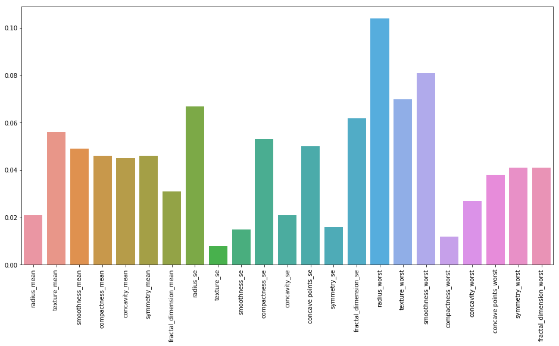

```python
feature_importance_df = pd.DataFrame(feature_importance, index=[0])
plt.figure(figsize=(16,8))
plt.xticks(rotation=90)
sns.barplot(data=feature_importance_df)
feature_importance_df.head()
#print(len(Xfs_train.columns), len(clf.feature_importances_))
#print(clf.feature_importances_)
```

## Evaluation Metrics

```python
from sklearn.metrics import accuracy_score, precision_score, recall_score, f1_score
print('Accuracy score: ', format(accuracy_score(yfs_test, yfs_pred)))
print('Precision score: ', format(precision_score(yfs_test, yfs_pred)))
print('Recall score: ', format(recall_score(yfs_test, yfs_pred)))
print('F1 score: ', format(f1_score(yfs_test, yfs_pred)))
print('Elapsed Time:', format(elapsed_time))
```

```
Accuracy score:  0.9473684210526315
Precision score:  0.975609756097561
Recall score:  0.8888888888888888
F1 score:  0.9302325581395349
Elapsed Time: 1.53125
```

## Tweaking Hyperparameters to improve score

```python
t = tm.process_time()
clf = AdaBoostClassifier(n_estimators=1000, learning_rate=0.9, random_state=19)
clf.fit(Xfs_train, yfs_train)
clf.feature_importances_
yfs_pred = clf.predict(Xfs_test)
elapsed_time = tm.process_time() - t

print('Accuracy score: ', format(accuracy_score(yfs_test, yfs_pred)))
print('Precision score: ', format(precision_score(yfs_test, yfs_pred)))
print('Recall score: ', format(recall_score(yfs_test, yfs_pred)))
print('F1 score: ', format(f1_score(yfs_test, yfs_pred)))
print('Elapsed Time:', format(elapsed_time))
```

```
Accuracy score:  0.956140350877193
Precision score:  1.0
Recall score:  0.8888888888888888
F1 score:  0.9411764705882353
Elapsed Time: 1.546875
```

## Building the Deep Neaural Network Model

```python
from keras.models import Sequential
from keras.layers import Dense

t = tm.process_time()
model = Sequential()
model.add(Dense(16, input_dim=23, activation='relu'))
model.add(Dense(16, input_dim=23, activation='relu'))
model.add(Dense(1, activation='sigmoid'))

model.compile(loss='binary_crossentropy', optimizer='rmsprop', metrics=['accuracy'])
```

## Fit Model

```python
model.fit(Xnfs_train, ynfs_train, epochs=1000, batch_size=32)
```

```
<keras.callbacks.History at 0x2062fa39400>
```

```python
ynfs_pred = model.predict(Xnfs_test)
elapsed_time = tm.process_time() - t
```

## Evaluation Metrics

```python
ynfs_pred_df = pd.DataFrame(np.round(ynfs_pred), columns=['Prediction'])
ynfs_pred_df.head()
```

|  | Prediction |
| --- | --- |
| 0 | 1.0 |
| 1 | 0.0 |
| 2 | 1.0 |
| 3 | 1.0 |
| 4 | 1.0 |

```python
print('Accuracy score: ', format(accuracy_score(ynfs_test, ynfs_pred_df)))
print('Precision score: ', format(precision_score(ynfs_test, ynfs_pred_df)))
print('Recall score: ', format(recall_score(ynfs_test, ynfs_pred_df)))
print('F1 score: ', format(f1_score(ynfs_test, ynfs_pred_df)))
print('Elapsed Time:', format(elapsed_time))
```

```
Accuracy score:  0.9736842105263158
Precision score:  0.9565217391304348
Recall score:  0.9777777777777777
F1 score:  0.967032967032967
Elapsed Time: 47.9375
```

## Exploring Hyperparameter Changes on Evaluation Metrics

- We will change batch size to see the impact it has on accuracy.
- We will also try to add DropOut Layers to see if it can improve results.

```python
t = tm.process_time()
model = Sequential()
model.add(Dense(16, input_dim=23, activation='relu'))
model.add(Dense(16, input_dim=23, activation='relu'))
model.add(Dense(1, activation='sigmoid'))

model.compile(loss='binary_crossentropy', optimizer='rmsprop', metrics=['accuracy'])
model.fit(Xnfs_train, ynfs_train, epochs=1000, batch_size=16)
ynfs_pred = model.predict(Xnfs_test)
elapsed_time = tm.process_time() - t
ynfs_pred_df = pd.DataFrame(np.round(ynfs_pred), columns=['Prediction'])
```

```python
print('Accuracy score: ', format(accuracy_score(ynfs_test, ynfs_pred_df)))
print('Precision score: ', format(precision_score(ynfs_test, ynfs_pred_df)))
print('Recall score: ', format(recall_score(ynfs_test, ynfs_pred_df)))
print('F1 score: ', format(f1_score(ynfs_test, ynfs_pred_df)))
print('Elapsed Time:', format(elapsed_time))
```

```
Accuracy score:  0.9736842105263158
Precision score:  1.0
Recall score:  0.9333333333333333
F1 score:  0.9655172413793104
Elapsed Time: 90.734375
```

```python
t = tm.process_time()
model = Sequential()
model.add(Dense(16, input_dim=23, activation='relu'))
model.add(Dense(16, input_dim=23, activation='relu'))
model.add(Dense(1, activation='sigmoid'))

model.compile(loss='binary_crossentropy', optimizer='rmsprop', metrics=['accuracy'])
model.fit(Xnfs_train, ynfs_train, epochs=1000, batch_size=64)
ynfs_pred = model.predict(Xnfs_test)
elapsed_time = tm.process_time() - t
ynfs_pred_df = pd.DataFrame(np.round(ynfs_pred), columns=['Prediction'])
```

```python
print('Accuracy score: ', format(accuracy_score(ynfs_test, ynfs_pred_df)))
print('Precision score: ', format(precision_score(ynfs_test, ynfs_pred_df)))
print('Recall score: ', format(recall_score(ynfs_test, ynfs_pred_df)))
print('F1 score: ', format(f1_score(ynfs_test, ynfs_pred_df)))
print('Elapsed Time:', format(elapsed_time))
```

```
Accuracy score:  0.9824561403508771
Precision score:  1.0
Recall score:  0.9555555555555556
F1 score:  0.9772727272727273
Elapsed Time: 27.09375
```

```python
from keras.layers import Dropout
t = tm.process_time()
model = Sequential()
model.add(Dense(16, input_dim=23, activation='relu'))
model.add(Dropout(0.4))
model.add(Dense(16, input_dim=23, activation='relu'))
model.add(Dropout(0.4))
model.add(Dense(1, activation='sigmoid'))

model.compile(loss='binary_crossentropy', optimizer='rmsprop', metrics=['accuracy'])
model.fit(Xnfs_train, ynfs_train, epochs=1000, batch_size=64)
ynfs_pred = model.predict(Xnfs_test)
elapsed_time = tm.process_time() - t
ynfs_pred_df = pd.DataFrame(np.round(ynfs_pred), columns=['Prediction'])
```

```python
print('Accuracy score: ', format(accuracy_score(ynfs_test, ynfs_pred_df)))
print('Precision score: ', format(precision_score(ynfs_test, ynfs_pred_df)))
print('Recall score: ', format(recall_score(ynfs_test, ynfs_pred_df)))
print('F1 score: ', format(f1_score(ynfs_test, ynfs_pred_df)))
print('Elapsed Time:', format(elapsed_time))
```

```
Accuracy score:  0.9649122807017544
Precision score:  0.9767441860465116
Recall score:  0.9333333333333333
F1 score:  0.9545454545454545
Elapsed Time: 37.796875
```

## Free Form Visulaization

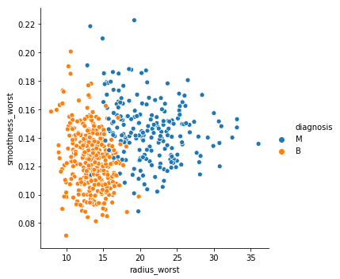

```python
sns.relplot(x="radius_worst", y="smoothness_worst", hue="diagnosis", data=data)
```

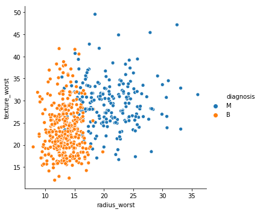

```python
sns.relplot(x="radius_worst", y="texture_worst", hue="diagnosis", data=data)
```

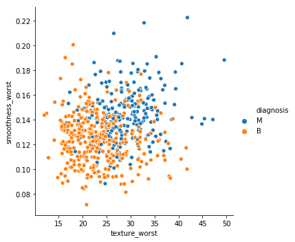

```python
sns.relplot(x="texture_worst", y="smoothness_worst", hue="diagnosis", data=data)
```

```python
worst_labels = data.columns[21:]
print(worst_labels)
```

```
Index(['radius_worst', 'texture_worst', 'perimeter_worst', 'area_worst',
       'smoothness_worst', 'compactness_worst', 'concavity_worst',
       'concave points_worst', 'symmetry_worst', 'fractal_dimension_worst'],
      dtype='object')
```

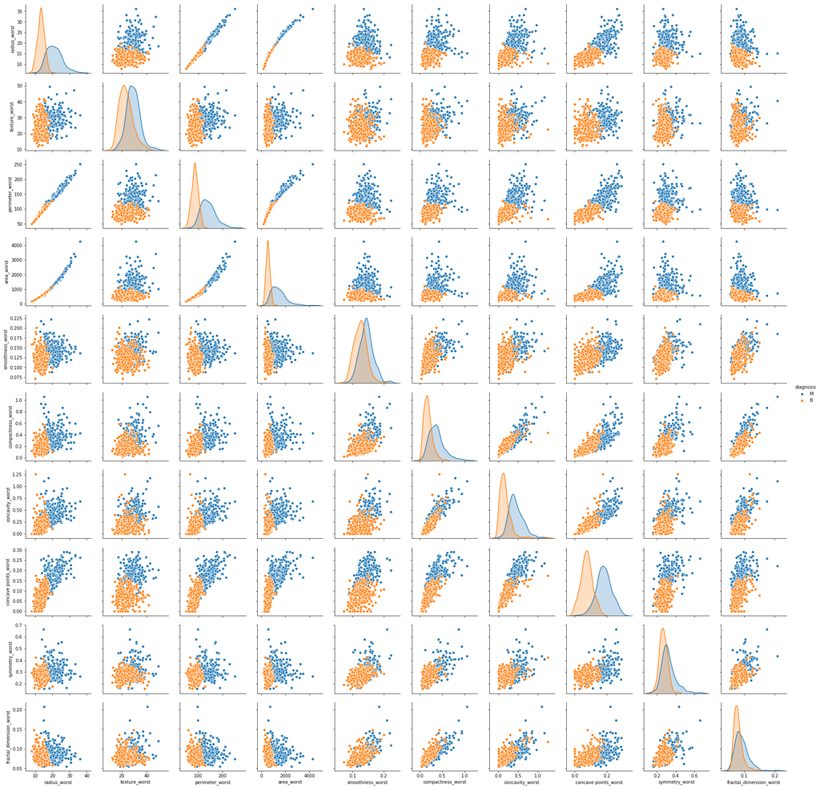

```python
sns.pairplot(data, vars=worst_labels, hue='diagnosis')
```

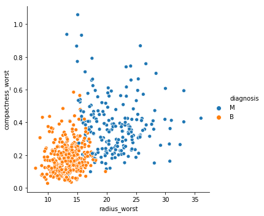

```python
sns.relplot(x="radius_worst", y="compactness_worst", hue="diagnosis", data=data)
```

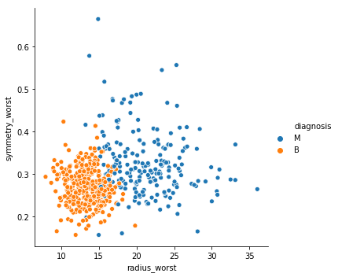

```python
sns.relplot(x="radius_worst", y="symmetry_worst", hue="diagnosis", data=data)
```

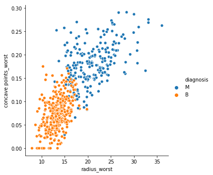

```python
sns.relplot(x="radius_worst", y="concave points_worst", hue="diagnosis", data=data)
```